[figure not shown]

# Differential gene abundance report

### differentialabundance workflow versionv2.0.0-g5cb5f98

2026-09-30

# Abstract

This report summarises differential gene analysis as performed by the nf-core/differentialabundance pipeline.

# Data

## Samples

A summary of sample metadata is below:

| Sample | Group | Condition | Injury |
| --- | --- | --- | --- |
| Sham_Sal_1 | Sham_sal | sal | Sham |
| Sham_oxy_1 | Sham_oxy | oxy | Sham |
| SNI_Sal_1 | SNI_sal | sal | SNI |
| SNI_oxy_1 | SNI_oxy | oxy | SNI |
| Sham_Sal_2 | Sham_sal | sal | Sham |
| Sham_oxy_2 | Sham_oxy | oxy | Sham |
| SNI_Sal_2 | SNI_sal | sal | SNI |
| SNI_oxy_2 | SNI_oxy | oxy | SNI |
| Sham_Sal_3 | Sham_sal | sal | Sham |
| Sham_oxy_3 | Sham_oxy | oxy | Sham |

[output cut: 6 more lines]

Sample metadata

## Contrasts

Comparisons were made between sample groups defined using sample metadata columns, as described in the following table of contrasts:

| Id | Variable | Reference | Target | Blocking | Formula | Make contrasts str |
| --- | --- | --- | --- | --- | --- | --- |
| Sham_oxy_vs_sal_study | group | Sham_sal | Sham_oxy |  |  |  |
| SNI_oxy_vs_sal_study | group | SNI_sal | SNI_oxy |  |  |  |

Table of contrasts

# Results

## Counts

Input was a matrix of 45706 genes for 16 samples, reduced to 26881 genes after filtering for low abundance.

### Filtering statistics

Filtering is applied to the input matrix according to the `--filtering_*` options, removing features that do not meet the specified criteria. This section summarizes the impact of each filtering rule, reporting how many genes were excluded per rule and how many passed all filters.

The following tables summarize retention and filtering failures.

| Metric | Count | Percent |
| --- | --- | --- |
| Total features | 45706 | 100 |
| Retained after filtering | 26881 | 58.8128473285783 |
| Removed by filtering | 18825 | 41.1871526714217 |

Filtering summary

| Rule | Threshold | Failed (any) | Failed (only this rule) |
| --- | --- | --- | --- |
| Minimum non-NA samples | 8 | 0 | 0 |
| Minimum abundance threshold | 1 | 18825 | 18825 |

Filtering rule breakdown (counts may overlap)

## Exploratory analysis

### Abundance value distributions

The following plots show the abundance value distributions of input matrices. A log2 transformation is applied where not already performed.

#### Box plots

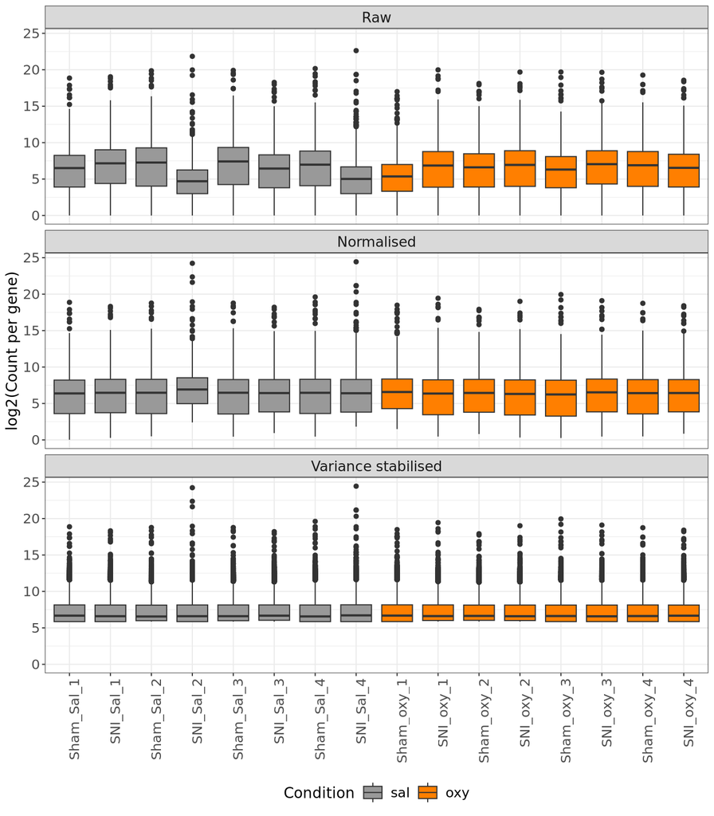

Whiskers in the above boxplots show 1.5 times the inter-quartile range.

#### Density plots

[interactive chart not shown]

### Sample relationships

#### Principal components plots

Principal components analysis was conducted based on the 500 most variable genes. Each component was annotated with its percent contribution to variance.

**Variance stabilised**

[interactive chart not shown]

**Normalised**

[interactive chart not shown]

**Raw**

[interactive chart not shown]

#### Scree plot

**Variance stabilised**

[interactive chart not shown]

**Normalised**

[interactive chart not shown]

**Raw**

[interactive chart not shown]

#### Principal components/ metadata associations

For the variance stabilised matrix, an ANOVA test was used to determine associations between continuous principal components and categorical covariates (including the variable of interest).

The resulting p values are illustrated below.

[interactive chart not shown]

The variable ‘condition’ shows an association with PC6 (5.3%) (p = 0.05). The variable ‘injury’ shows an association with PC4 (7.7%) (p = 0.08).

#### Clustering heatmaps

**Variance stabilised**

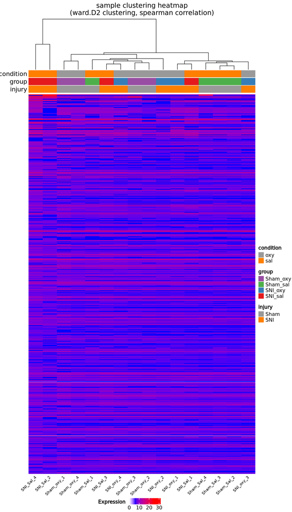

**Normalised**

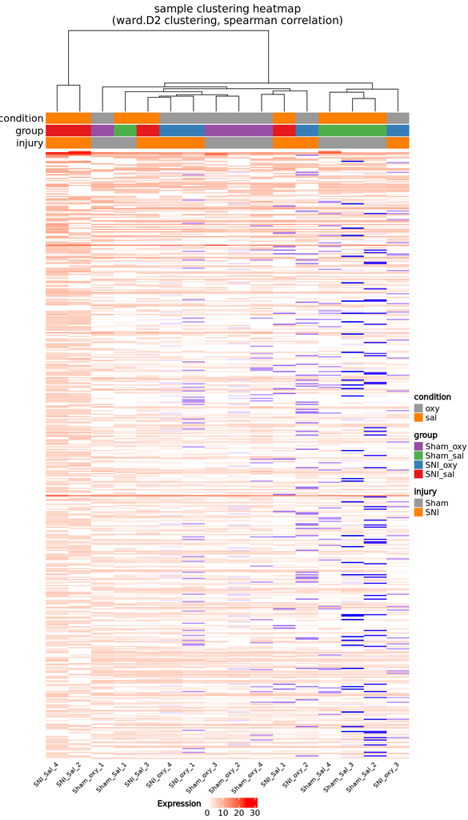

**Raw**

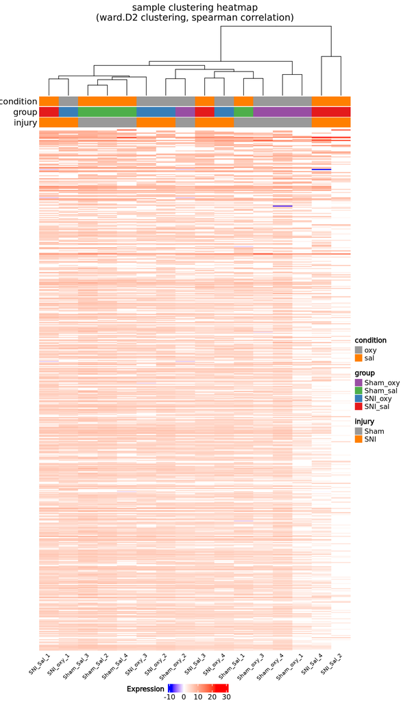

### Outlier detection

**condition**

[interactive chart not shown]

2 possible outliers were detected in groups defined by condition: Sham_oxy_1, SNI_Sal_2

**group**

[interactive chart not shown]

No outlying samples were detected in groups defined by group.

**injury**

[interactive chart not shown]

3 possible outliers were detected in groups defined by injury: Sham_oxy_1, SNI_Sal_2, SNI_Sal_4

## Differential analysis

### Differential gene counts

**Adjusted**

|  | up | down |
| --- | --- | --- |
| Sham_oxy versus Sham_sal in group | 7 | 0 |
| SNI_oxy versus SNI_sal in group | 1 | 17 |

Differential gene (target relative to reference)

**Unadjusted**

|  | up | down |
| --- | --- | --- |
| Sham_oxy versus Sham_sal in group | 9 | 1 |
| SNI_oxy versus SNI_sal in group | 1 | 26 |

Differential gene (target relative to reference)

### Upset plot

**Adjusted**

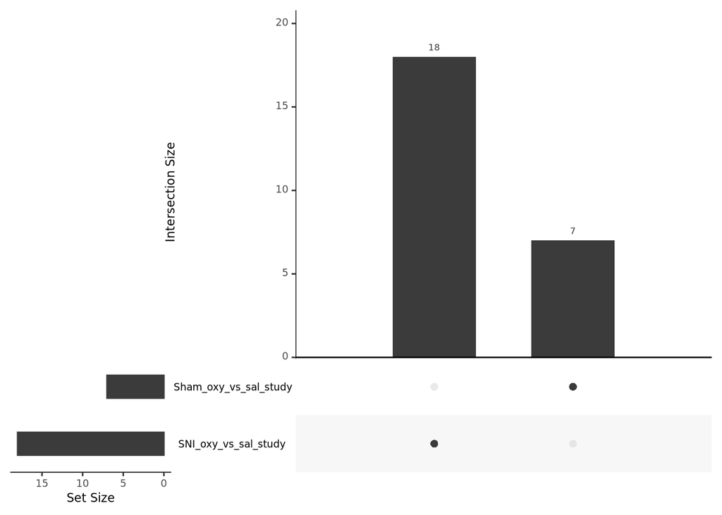

**Unadjusted**

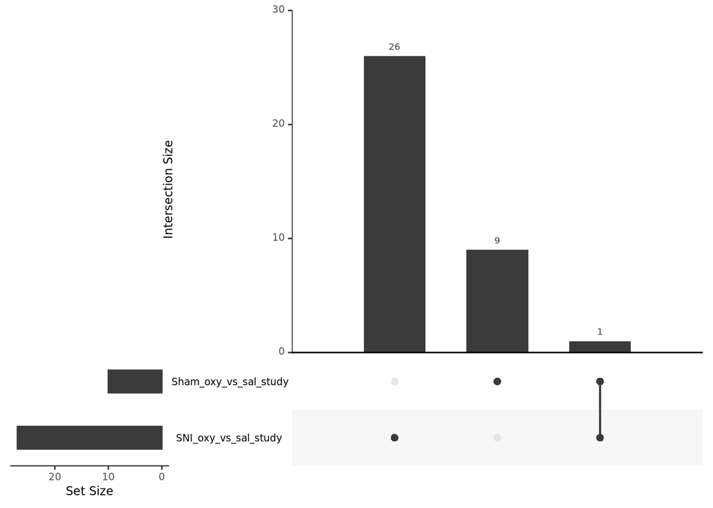

### Differential gene details

#### Sham_oxy versus Sham_sal in group

**Adjusted p values**

[interactive chart not shown]

###### Differential Genes Table

| Direction | Gene id | Gene name | Pvalue | Padj | Log2FoldChange |
| --- | --- | --- | --- | --- | --- |
| Up | ENSMUSG00000090546 | Cdr1 | 5.80592851671378e-10 | 6.52528305993462e-06 | 17.181683350596 |
| Up | ENSMUSG00000026058 | Khdrbs2 | 3.22829680642846e-09 | 1.81414139037247e-05 | 1.0027645168264 |
| Up | ENSMUSG00000040452 | Cdh12 | 5.42117725881422e-07 | 0.00112312456388689 | 1.31871417814164 |
| Up | ENSMUSG00000103497 | Gm37407 | 7.26883108125683e-07 | 0.00112312456388689 | 1.13949527894259 |
| Up | ENSMUSG00000021609 | Slc6a3 | 7.99448039068875e-07 | 0.00112312456388689 | 4.28707431764412 |
| Up | ENSMUSG00000030110 | Ret | 3.12071868651881e-06 | 0.00311333383581761 | 1.68540122431002 |
| Up | ENSMUSG00000106855 | RP23-301C7.2 | 6.53278097391373e-06 | 0.00489479502438776 | 1.01431109083897 |

Differential genes (Up + Down) in Sham_oxy versus Sham_sal in group (check .//Sham_oxy_vs_sal_study.deseq2.results.tsv for more detail)

**Box plots**

The following box plots show the distribution of expression levels for the top 10 genes ranked by significance.

**Variance stabilised**

[interactive chart not shown]

**Normalised**

[interactive chart not shown]

**Raw**

[interactive chart not shown]

Column ‘Gene biotype’ does not exist. Skipping plot.

**Unadjusted p values**

[interactive chart not shown]

###### Differential Genes Table

[output not shown]

Differential genes (Up + Down) in Sham_oxy versus Sham_sal in group (check .//Sham_oxy_vs_sal_study.deseq2.results.tsv for more detail)

**Box plots**

The following box plots show the distribution of expression levels for the top 10 genes ranked by significance.

**Variance stabilised**

[interactive chart not shown]

**Normalised**

[interactive chart not shown]

**Raw**

[interactive chart not shown]

Column ‘Gene biotype’ does not exist. Skipping plot.

#### SNI_oxy versus SNI_sal in group

**Adjusted p values**

[interactive chart not shown]

###### Differential Genes Table

| Direction | Gene id | Gene name | Pvalue | Padj | Log2FoldChange |
| --- | --- | --- | --- | --- | --- |
| Down | ENSMUSG00000106106 | Rn18s-rs5 | 4.24393132777155e-14 | 7.85976081903291e-10 | -11.1483339968554 |
| Down | ENSMUSG00000035202 | Lars2 | 1.6323825605881e-08 | 0.000151158625110458 | -9.61842297347807 |
| Up | ENSMUSG00000020914 | Top2a | 2.49943311462489e-07 | 0.00148350231415176 | 2.42146633058161 |
| Down | ENSMUSG00000074782 | 4833422C13Rik | 3.2041086698742e-07 | 0.00148350231415176 | -3.47827767193391 |
| Down | ENSMUSG00000065922 | n-R5-8s1 | 1.51857043465684e-06 | 0.00562478488996892 | -7.80030013187741 |
| Down | ENSMUSG00000032532 | Cck | 2.1700476938106e-06 | 0.00669821388156204 | -2.15961263237489 |
| Down | ENSMUSG00000102969 | Gm33366 | 3.41998890307796e-06 | 0.00876890555298978 | -4.31655345408726 |
| Down | ENSMUSG00000096947 | Gm26723 | 3.78786416975801e-06 | 0.00876890555298978 | -5.64549292737699 |
| Down | ENSMUSG00000047485 | Klhl34 | 4.91408722263778e-06 | 0.0101120994848057 | -4.6925176328608 |
| Down | ENSMUSG00000073867 | AA474408 | 8.31979842457382e-06 | 0.014007515165737 | -2.30569921597032 |

[output cut: 8 more lines]

Differential genes (Up + Down) in SNI_oxy versus SNI_sal in group (check .//SNI_oxy_vs_sal_study.deseq2.results.tsv for more detail)

**Box plots**

The following box plots show the distribution of expression levels for the top 10 genes ranked by significance.

**Variance stabilised**

[interactive chart not shown]

**Normalised**

[interactive chart not shown]

**Raw**

[interactive chart not shown]

Column ‘Gene biotype’ does not exist. Skipping plot.

**Unadjusted p values**

[interactive chart not shown]

###### Differential Genes Table

| Direction | Gene id | Gene name | Pvalue | Padj | Log2FoldChange |
| --- | --- | --- | --- | --- | --- |
| Down | ENSMUSG00000106106 | Rn18s-rs5 | 4.24393132777155e-14 | 7.85976081903291e-10 | -11.1483339968554 |
| Down | ENSMUSG00000035202 | Lars2 | 1.6323825605881e-08 | 0.000151158625110458 | -9.61842297347807 |
| Up | ENSMUSG00000020914 | Top2a | 2.49943311462489e-07 | 0.00148350231415176 | 2.42146633058161 |
| Down | ENSMUSG00000074782 | 4833422C13Rik | 3.2041086698742e-07 | 0.00148350231415176 | -3.47827767193391 |
| Down | ENSMUSG00000065922 | n-R5-8s1 | 1.51857043465684e-06 | 0.00562478488996892 | -7.80030013187741 |
| Down | ENSMUSG00000032532 | Cck | 2.1700476938106e-06 | 0.00669821388156204 | -2.15961263237489 |
| Down | ENSMUSG00000102969 | Gm33366 | 3.41998890307796e-06 | 0.00876890555298978 | -4.31655345408726 |
| Down | ENSMUSG00000096947 | Gm26723 | 3.78786416975801e-06 | 0.00876890555298978 | -5.64549292737699 |
| Down | ENSMUSG00000047485 | Klhl34 | 4.91408722263778e-06 | 0.0101120994848057 | -4.6925176328608 |
| Down | ENSMUSG00000073867 | AA474408 | 8.31979842457382e-06 | 0.014007515165737 | -2.30569921597032 |

[output cut: 17 more lines]

Differential genes (Up + Down) in SNI_oxy versus SNI_sal in group (check .//SNI_oxy_vs_sal_study.deseq2.results.tsv for more detail)

**Box plots**

The following box plots show the distribution of expression levels for the top 10 genes ranked by significance.

**Variance stabilised**

[interactive chart not shown]

**Normalised**

[interactive chart not shown]

**Raw**

[interactive chart not shown]

Column ‘Gene biotype’ does not exist. Skipping plot.

# Methods

## Filtering

| Parameter | Value |
| --- | --- |
| min_samples | 1 |
| min_abundance | 1 |
| min_proportion_not_na | 0.5 |
| tests | study.tests.tsv |
| thresholds | study.thresholds.tsv |

Parameters used for feature-wise filtering

Filtering was carried out by selecting genes with an abundance of at least 1 in at least 1 samples.

## Exploratory analysis

| Parameter | Value |
| --- | --- |
| main_variable | auto_pca |
| clustering_method | ward.D2 |
| cor_method | spearman |
| n_features | 500 |
| whisker_distance | 1.5 |
| mad_threshold | -5 |
| assay_names | raw,normalised,variance_stabilised |
| final_assay | variance_stabilised |
| log2_assays | raw,normalised |
| palette_name | Set1 |

Parameters used for exploratory analysis

## Differential analysis

| Parameter | Value |
| --- | --- |
| test | Wald |
| fit_type | parametric |
| sf_type | ratio |
| min_replicates_for_replace | 7 |
| use_t | FALSE |
| lfc_threshold | 0 |
| alt_hypothesis | greaterAbs |
| independent_filtering | TRUE |
| p_adjust_method | BH |
| alpha | 0.1 |

[output cut: 5 more lines]

Parameters used for DESeq2

| Parameter | Value |
| --- | --- |
| method | deseq2 |
| file_suffix | .deseq2.results.tsv |
| feature_id_column | gene_id |
| min_fold_change | 2 |
| max_pval | 1 |
| max_qval | 0.05 |
| palette_name | Set1 |
| subset_to_contrast_samples | FALSE |
| fc_column | log2FoldChange |
| pval_column | pvalue |

[output cut: 2 more lines]

Parameters used for downstream differential analysis

### Gene set analysis

#### NONE

| Parameter | Value |
| --- | --- |

Parameters used for NONE

# Appendices

## All parameters

| Parameter | Value |
| --- | --- |
| input_dir | ./ |
| id | study |
| paramset_name | rnaseq |
| input | data/samplesheet.csv |
| contrasts | data/contrasts.csv |
| matrix | data/salmon.merged.gene_counts.tsv |
| features_id_col | gene_id |
| features_name_col | gene_name |
| features_metadata_cols | gene_id,gene_name |
| report_file | report_fixed.qmd |

[output cut: 158 more lines]

## Software versions

**Note:** For a more detailed accounting of the software and commands used (including containers), consult the execution report produced as part of the ‘pipeline info’ for this workflow.

| Component | Software | Version |
| --- | --- | --- |
| CSVTK_JOIN | csvtk | 0.37.0 |
| CUSTOM_FILTERDIFFERENTIALTABLE | pandas | 1.5.2 |
| CUSTOM_FILTERDIFFERENTIALTABLE | python | 3.11.15 |
| CUSTOM_MATRIXFILTER | r-base | 4.2.1 |
| DESEQ2_DIFFERENTIAL | r-base | 4.1.3 |
| DESEQ2_DIFFERENTIAL | bioconductor-deseq2 | 1.34.0 |
| DESEQ2_NORM | r-base | 4.1.3 |
| DESEQ2_NORM | bioconductor-deseq2 | 1.34.0 |
| PLOT_DIFFERENTIAL | shinyngs | 2.4.0 |
| PLOT_EXPLORATORY | shinyngs | 2.4.0 |

[output cut: 4 more lines]

Software versions

# nf-core/differentialabundance: Citations

## [nf-core](https://pubmed.ncbi.nlm.nih.gov/32055031/)

> Ewels PA, Peltzer A, Fillinger S, Patel H, Alneberg J, Wilm A, Garcia MU, Di Tommaso P, Nahnsen S. The nf-core framework for community-curated bioinformatics pipelines. Nat Biotechnol. 2020 Mar;38(3):276-278. doi: 10.1038/s41587-020-0439-x. PubMed PMID: 32055031.

## [Nextflow](https://pubmed.ncbi.nlm.nih.gov/28398311/)

> Di Tommaso P, Chatzou M, Floden EW, Barja PP, Palumbo E, Notredame C. Nextflow enables reproducible computational workflows. Nat Biotechnol. 2017 Apr 11;35(4):316-319. doi: 10.1038/nbt.3820. PubMed PMID: 28398311.

## Pipeline tools

- [decoupler-py](https://pubmed.ncbi.nlm.nih.gov/36699385/)

  > Badia-i-Mompel P, Vélez Santiago J, Braunger J, Geiss C, Dimitrov D, Müller-Dott S, Taus P, Dugourd A, Holland CH, Ramirez Flores RO, Saez-Rodriguez J. decoupleR: ensemble of computational methods to infer biological activities from omics data. Bioinform Adv. 2022 Mar 8;2(1):vbac016. doi: 10.1093/bioadv/vbac016. PubMed PMID: 36699385; PubMed Central PMCID: PMC9710656.
- [GSEA](https://www.gsea-msigdb.org/gsea/index.jsp)

  > Subramanian A, Tamayo P, Mootha VK, et al. Gene set enrichment analysis: a knowledge-based approach for interpreting genome-wide expression profiles. Proc Natl Acad Sci U S A. 2005;102(43):15545-15550.

## R packages

- [affy](https://pubmed.ncbi.nlm.nih.gov/14960456/)

  > Gautier L, Cope L, Bolstad BM, Irizarry RA. Affy–analysis of affymetrix genechip data at the probe level. Bioinformatics. 2004;20(3):307-315.
- [DESeq2](https://pubmed.ncbi.nlm.nih.gov/25516281/)

  > Love MI, Huber W, Anders S (2014). Moderated estimation of fold change and dispersion for RNA-seq data with DESeq2. Genome Biol. 15(12):550. PubMed PMID: 25516281; PubMed Central PMCID: PMC4302049.
- [GEOQuery](https://pubmed.ncbi.nlm.nih.gov/17496320/)

  > Davis S, Meltzer PS. Geoquery: a bridge between the gene expression omnibus (Geo) and bioconductor. Bioinformatics. 2007;23(14):1846-1847.
- [ggplot2](https://cran.r-project.org/web/packages/ggplot2/index.html)

  > H. Wickham (2016). ggplot2: Elegant Graphics for Data Analysis. Springer-Verlag New York.
- [gprofiler2](https://cran.r-project.org/web/packages/gprofiler2/index.html)

  > Kolberg L, Raudvere U, Kuzmin I, Vilo J, Peterson H (2020). “gprofiler2– an R package for gene list functional enrichment analysis and namespace conversion toolset g:Profiler.” F1000Research, 9 (ELIXIR)(709). R package version 0.2.2.
- [Limma](https://pubmed.ncbi.nlm.nih.gov/25605792/)

  > Ritchie ME, Phipson B, Wu D, et al. Limma powers differential expression analyses for rna-sequencing and microarray studies. Nucleic Acids Res. 2015;43(7):e47.
- optparse

  > Trevor L Davis (2018). optparse: Command Line Option Parser.
- [plotly](https://plotly.com/r/)

  > C. Sievert (2020). Interactive Web-Based Data Visualization with R, plotly, and shiny. Chapman and Hall/CRC Florida.
- [Proteus](https://doi.org/10.1101/416511)

  > Gierlinski M, Gastaldello F, Cole C, Barton GJ. Proteus : An r Package for Downstream Analysis of Maxquant Output. Bioinformatics; 2018.
- [R](https://www.R-project.org/)

  > R Core Team (2017). R: A language and environment for statistical computing. R Foundation for Statistical Computing, Vienna, Austria.
- RColorBrewer

  > Erich Neuwirth (2014). RColorBrewer: ColorBrewer Palettes.
- [RMarkdown](https://rmarkdown.rstudio.com)

  > JJ Allaire and Yihui Xie and Jonathan McPherson and Javier Luraschi and Kevin Ushey and Aron Atkins and Hadley Wickham and Joe Cheng and Winston Chang and Richard Iannone (2022). rmarkdown: Dynamic Documents for R.
- shinyngs

  > Jonathan R Manning (2022). Shiny apps for NGS etc based on reusable components created using Shiny modules. Computer software. Vers. 1.5.3. Jonathan Manning, Dec. 2022. Web.
- [SummarizedExperiment](https://bioconductor.org/packages/release/bioc/html/SummarizedExperiment.html)

  > Morgan M, Obenchain V, Hester J and Pagès H (2020). SummarizedExperiment: SummarizedExperiment container.
- [variancePartition](https://pubmed.ncbi.nlm.nih.gov/27884101/)

  > Hoffman GE, Schadt EE. variancePartition: interpreting drivers of variation in complex gene expression studies. BMC Bioinformatics. 2016 Nov 25;17(1):483. doi: 10.1186/s12859-016-1323-z. PubMed PMID: 27884101; PubMed Central PMCID: PMC5123296.
- [variancePartition::dream](https://pubmed.ncbi.nlm.nih.gov/32730587/)

  > Hoffman GE, Roussos P. Dream: powerful differential expression analysis for repeated measures designs. Bioinformatics. 2021 Apr 19;37(2):192-201. doi: 10.1093/bioinformatics/btaa687. PubMed PMID: 32730587; PubMed Central PMCID: PMC8055218.

## Software packaging/containerisation tools

- [Anaconda](https://anaconda.com)

  > Anaconda Software Distribution. Computer software. Vers. 2-2.4.0. Anaconda, Nov. 2016. Web.
- [Bioconda](https://pubmed.ncbi.nlm.nih.gov/29967506/)

  > Grüning B, Dale R, Sjödin A, Chapman BA, Rowe J, Tomkins-Tinch CH, Valieris R, Köster J; Bioconda Team. Bioconda: sustainable and comprehensive software distribution for the life sciences. Nat Methods. 2018 Jul;15(7):475-476. doi: 10.1038/s41592-018-0046-7. PubMed PMID: 29967506.
- [BioContainers](https://pubmed.ncbi.nlm.nih.gov/28379341/)

  > da Veiga Leprevost F, Grüning B, Aflitos SA, Röst HL, Uszkoreit J, Barsnes H, Vaudel M, Moreno P, Gatto L, Weber J, Bai M, Jimenez RC, Sachsenberg T, Pfeuffer J, Alvarez RV, Griss J, Nesvizhskii AI, Perez-Riverol Y. BioContainers: an open-source and community-driven framework for software standardization. Bioinformatics. 2017 Aug 15;33(16):2580-2582. doi: 10.1093/bioinformatics/btx192. PubMed PMID: 28379341; PubMed Central PMCID: PMC5870671.
- [Docker](https://dl.acm.org/doi/10.5555/2600239.2600241)

  > Merkel, D. (2014). Docker: lightweight linux containers for consistent development and deployment. Linux Journal, 2014(239), 2. doi: 10.5555/2600239.2600241.
- [Singularity](https://pubmed.ncbi.nlm.nih.gov/28494014/)

  > Kurtzer GM, Sochat V, Bauer MW. Singularity: Scientific containers for mobility of compute. PLoS One. 2017 May 11;12(5):e0177459. doi: 10.1371/journal.pone.0177459. eCollection 2017. PubMed PMID: 28494014; PubMed Central PMCID: PMC5426675.